# 2 Menstrual bleeding and pain ePRO results

## 2.1 Overview

Percentages in the overview use all submitted participant records as the denominator. Conditional questions use only the participants for whom that question was relevant under the XLSForm skip logic.

Participants analysed

240

Reported bleeding

148 (61.7%)

Reported menstrual pain

105 (43.8%)

Severe/very severe among pain reporters

22 (21.0%)

## 2.2 Menstrual bleeding

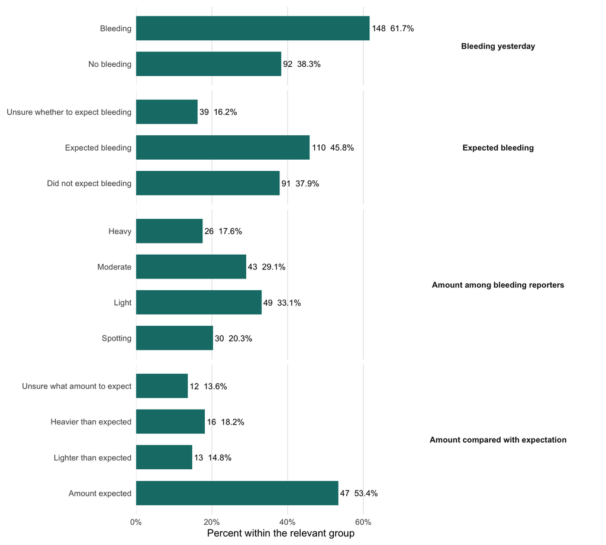

## 2.3 Menstrual pain

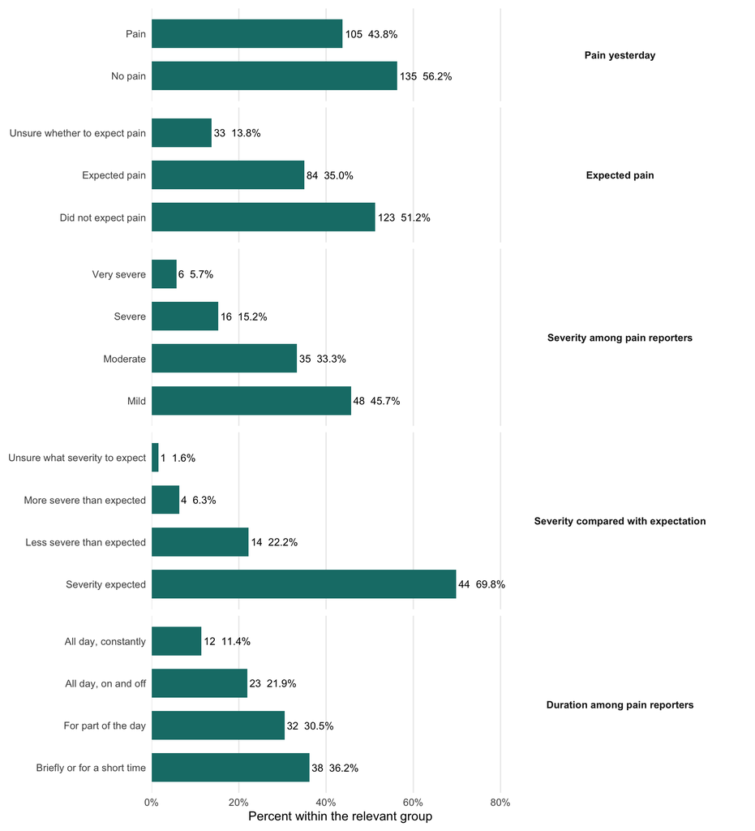

## 2.4 Bleeding and pain together

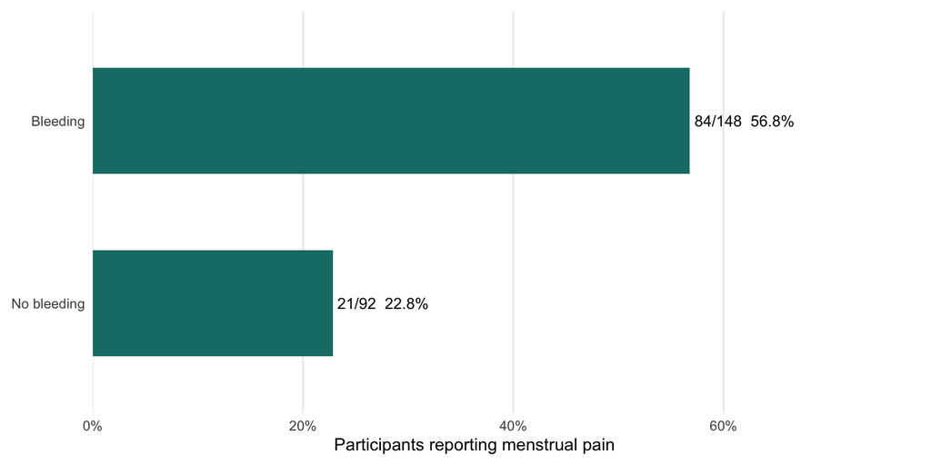

## 2.5 Pain location map

Left and right members of an otherwise identical region pair are combined. Hands and feet also ignore dorsal/ventral surface. Arms are grouped as fore, mid, or upper; legs are grouped as lower or upper. A participant selecting more than one component of a combined region contributes once to that region.

[figure not shown]

0% Percent of participants 7.1%

Hover over or focus any combined limb component to see its participant count and percentage.

### 2.5.1 Most frequently selected pain regions

| Region | Participants | Percent of participants |
| --- | --- | --- |
| Dorsal Flank | 17 | 7.1% |
| Ventral Abdomen Lower | 17 | 7.1% |
| Dorsal Back Lumbar | 16 | 6.7% |
| Ventral Pubic | 14 | 5.8% |
| Dorsal Buttock | 13 | 5.4% |
| Ventral Abdomen Side | 11 | 4.6% |
| Ventral Abdomen Upper | 11 | 4.6% |
| Leg Upper | 10 | 4.2% |
| Dorsal Back Lumbar Central | 9 | 3.8% |
| Ventral Hip | 8 | 3.3% |
| Ventral Abdomen Lower Central | 7 | 2.9% |
| Arm Mid | 6 | 2.5% |
| Hand | 6 | 2.5% |
| Ventral Chest Upper | 6 | 2.5% |
| Breast | 5 | 2.1% |

Since participants can select multiple pain regions, the location percentages are not expected to sum to 100%.

## 2.6 Data-quality checks

| Check | Issues |
| --- | --- |
| Duplicate participant IDs | 0 |
| Bleeding amount present when no bleeding was reported | 0 |
| Bleeding expectation comparison outside its skip condition | 0 |
| Pain severity present when no pain was reported | 0 |
| Pain duration present when no pain was reported | 0 |
| Pain locations present when no pain was reported | 0 |
| Pain expectation comparison outside its skip condition | 0 |
| Unmatched body-map response codes | 0 |

## 2.7 Analysis notes

- Each row is treated as one participant submission.
- Overall bleeding and pain percentages use all submitted rows as the denominator.
- Severity, amount, duration, and comparison-with-expectation questions use only rows for which the XLSForm says the question is relevant.
- This is descriptive analysis. The report does not test causal relationships or make clinical interpretations.